# Prediction Assignment Writeup

## Cross-validation

```r
set.seed(1234)
inTrain <- createDataPartition(y=training$classe,
                               p=0.7,
                               list=FALSE)
training_1 <- training[inTrain,]
training_2 <- training[-inTrain,]
dim(training_1); dim(training_2)
```

```
## [1] 13737    54
```

```
## [1] 5885   54
```

# Training

I want to predict the ‘classe’ variable in the training set. The variables ‘classe’ has 5 outcomes:

- A: Sitting
- B: Sitting down
- C: Standing
- D: Standing Up
- E: Walking

```r
unique(training$classe)
```

```
## [1] A B C D E
## Levels: A B C D E
```

This means I need to predict a classification as outcome, so predicting with (boosted) trees, random forest (set of trees) or linear discriminant analysis seems appropriate.

## Modeling

Modeling with trees

```r
set.seed(12345)
modFitDecTree <- train(classe ~ ., method = 'rpart', data = training_1)
library(rattle)
```

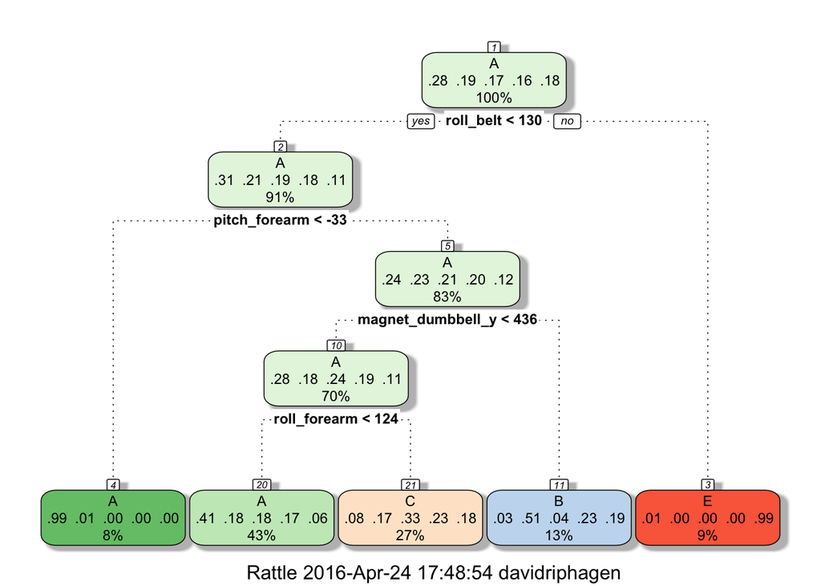

```r
fancyRpartPlot(modFitDecTree$finalModel)
```

Modeling with random forests

```r
modFit_rf <- train(classe ~ ., method = 'rf', data = training_1)
```

Modeling with Boosted trees

```r
modFit_gbm <- train(classe ~ .,
                    method="gbm",
                    data=training_1)
```

Modeling with linear discriminant analysis (“lda”) model

```r
modFit_lda <- train(classe ~ .,
                    method="lda",
                    data=training)
```

# Testing

## Cross-validation

Decision tree

```r
predictDecTree <- predict(modFitDecTree, newdata=training_2)
confMatDecTree <- confusionMatrix(predictDecTree, training_2$classe)
confMatDecTree
```

```
## Confusion Matrix and Statistics
##
##           Reference
## Prediction    A    B    C    D    E
##          A 1530  486  493  452  168
##          B   35  379   31  164  145
##          C  105  274  502  348  302
##          D    0    0    0    0    0
##          E    4    0    0    0  467
##
## Overall Statistics
##
##                Accuracy : 0.489
##                  95% CI : (0.4762, 0.5019)
##     No Information Rate : 0.2845
##     P-Value [Acc > NIR] : < 2.2e-16
##
##                   Kappa : 0.3311
##  Mcnemar's Test P-Value : NA
##
## Statistics by Class:
##
##                      Class: A Class: B Class: C Class: D Class: E
## Sensitivity            0.9140   0.3327   0.4893   0.0000  0.43161
## Specificity            0.6203   0.9210   0.7882   1.0000  0.99917
## Pos Pred Value         0.4890   0.5027   0.3279      NaN  0.99151
## Neg Pred Value         0.9478   0.8519   0.8797   0.8362  0.88641
## Prevalence             0.2845   0.1935   0.1743   0.1638  0.18386
## Detection Rate         0.2600   0.0644   0.0853   0.0000  0.07935
## Detection Prevalence   0.5317   0.1281   0.2602   0.0000  0.08003
## Balanced Accuracy      0.7671   0.6269   0.6388   0.5000  0.71539
```

Accuracy is

```r
confMatDecTree$overall['Accuracy']
```

```
##  Accuracy
## 0.4890399
```

Boosted trees

```r
gbm_predictions <- predict(modFit_gbm, training_2)
confusionMatrix(gbm_predictions, training_2$classe)
```

```
## Confusion Matrix and Statistics
##
##           Reference
## Prediction    A    B    C    D    E
##          A 1674   14    0    0    0
##          B    0 1110    7    8    1
##          C    0   11 1017    9    3
##          D    0    4    2  947    6
##          E    0    0    0    0 1072
##
## Overall Statistics
##
##                Accuracy : 0.989
##                  95% CI : (0.9859, 0.9915)
##     No Information Rate : 0.2845
##     P-Value [Acc > NIR] : < 2.2e-16
##
##                   Kappa : 0.986
##  Mcnemar's Test P-Value : NA
##
## Statistics by Class:
##
##                      Class: A Class: B Class: C Class: D Class: E
## Sensitivity            1.0000   0.9745   0.9912   0.9824   0.9908
## Specificity            0.9967   0.9966   0.9953   0.9976   1.0000
## Pos Pred Value         0.9917   0.9858   0.9779   0.9875   1.0000
## Neg Pred Value         1.0000   0.9939   0.9981   0.9965   0.9979
## Prevalence             0.2845   0.1935   0.1743   0.1638   0.1839
## Detection Rate         0.2845   0.1886   0.1728   0.1609   0.1822
## Detection Prevalence   0.2868   0.1913   0.1767   0.1630   0.1822
## Balanced Accuracy      0.9983   0.9856   0.9932   0.9900   0.9954
```

Accuracy is

```r
confusionMatrix(gbm_predictions, training_2$classe)$overall['Accuracy']
```

```
## Accuracy
## 0.988955
```

Random forest

```r
rf_predictions <- predict(modFit_rf, training_2)
confusionMatrix(rf_predictions, training_2$classe)
```

```
## Confusion Matrix and Statistics
##
##           Reference
## Prediction    A    B    C    D    E
##          A 1674    4    0    0    0
##          B    0 1134    2    0    0
##          C    0    1 1024    1    0
##          D    0    0    0  963    4
##          E    0    0    0    0 1078
##
## Overall Statistics
##
##                Accuracy : 0.998
##                  95% CI : (0.9964, 0.9989)
##     No Information Rate : 0.2845
##     P-Value [Acc > NIR] : < 2.2e-16
##
##                   Kappa : 0.9974
##  Mcnemar's Test P-Value : NA
##
## Statistics by Class:
##
##                      Class: A Class: B Class: C Class: D Class: E
## Sensitivity            1.0000   0.9956   0.9981   0.9990   0.9963
## Specificity            0.9991   0.9996   0.9996   0.9992   1.0000
## Pos Pred Value         0.9976   0.9982   0.9981   0.9959   1.0000
## Neg Pred Value         1.0000   0.9989   0.9996   0.9998   0.9992
## Prevalence             0.2845   0.1935   0.1743   0.1638   0.1839
## Detection Rate         0.2845   0.1927   0.1740   0.1636   0.1832
## Detection Prevalence   0.2851   0.1930   0.1743   0.1643   0.1832
## Balanced Accuracy      0.9995   0.9976   0.9988   0.9991   0.9982
```

Accuracy is

```r
confusionMatrix(rf_predictions, training_2$classe)$overall['Accuracy']
```

```
##  Accuracy
## 0.9979609
```

Linear Discriminant Analysis

```r
lda_predictions <- predict(modFit_lda, training_2)
confusionMatrix(lda_predictions, training_2$classe)
```

```
## Confusion Matrix and Statistics
##
##           Reference
## Prediction    A    B    C    D    E
##          A 1393  151   98   51   47
##          B   49  751   91   36  154
##          C  107  145  678  114   91
##          D  120   47  127  732  105
##          E    5   45   32   31  685
##
## Overall Statistics
##
##                Accuracy : 0.7203
##                  95% CI : (0.7086, 0.7317)
##     No Information Rate : 0.2845
##     P-Value [Acc > NIR] : < 2.2e-16
##
##                   Kappa : 0.6461
##  Mcnemar's Test P-Value : < 2.2e-16
##
## Statistics by Class:
##
##                      Class: A Class: B Class: C Class: D Class: E
## Sensitivity            0.8321   0.6594   0.6608   0.7593   0.6331
## Specificity            0.9176   0.9305   0.9059   0.9189   0.9765
## Pos Pred Value         0.8006   0.6947   0.5974   0.6472   0.8584
## Neg Pred Value         0.9322   0.9192   0.9267   0.9512   0.9220
## Prevalence             0.2845   0.1935   0.1743   0.1638   0.1839
## Detection Rate         0.2367   0.1276   0.1152   0.1244   0.1164
## Detection Prevalence   0.2957   0.1837   0.1929   0.1922   0.1356
## Balanced Accuracy      0.8749   0.7949   0.7834   0.8391   0.8048
```

Accuracy is

```r
confusionMatrix(lda_predictions, training_2$classe)$overall['Accuracy']
```

```
##  Accuracy
## 0.7203059
```

## Predicting the testing set

```r
overall_predictions <- predict(modFit_rf, testing)
```

And I write the data to a file:

```r
write.table(overall_predictions,
            "predictions.txt",
            sep="\t",
            quote=FALSE,
            row.names=c("problem_id_1", "problem_id_2", "problem_id_3", "problem_id_4", "problem_id_5", "problem_id_6", "problem_id_7", "problem_id_8", "problem_id_9", "problem_id_10", "problem_id_11", "problem_id_12", "problem_id_13", "problem_id_14", "problem_id_15", "problem_id_16", "problem_id_17", "problem_id_18", "problem_id_19", "problem_id_20"),
            col.names=c("predicted_class")
            )
```